# Reproducible data analysis (Project One)

JYu

26/04/2020

# **This is the submission document for Assingment One of the Reproducible Data Ananlysis Course**

#Part 1: Loading data ##Task one: code to load the data

```r
#setting working directory
setwd<- "C:/Users/jiameng.yu/Desktop/Statistics_course/Course 5 - Reproducible Research/Course project 1"
rawData <- read.csv("repdata_data_activity/activity.csv")
head(rawData)
```

```
##   steps       date interval
## 1    NA 2012-10-01        0
## 2    NA 2012-10-01        5
## 3    NA 2012-10-01       10
## 4    NA 2012-10-01       15
## 5    NA 2012-10-01       20
## 6    NA 2012-10-01       25
```

```r
str(rawData)
```

```
## 'data.frame':    17568 obs. of  3 variables:
##  $ steps   : int  NA NA NA NA NA NA NA NA NA NA ...
##  $ date    : Factor w/ 61 levels "2012-10-01","2012-10-02",..: 1 1 1 1 1 1 1 1 1 1 ...
##  $ interval: int  0 5 10 15 20 25 30 35 40 45 ...
```

##Task 2: transforming data ###date is saved as Factor. This variable needs to be transformed.

```r
library(dplyr)
processData1<-  mutate(rawData,Date=as.Date(rawData$date,"%Y-%m-%d"))
cleanData <- select(processData1,-date)
str(cleanData)
```

```
## 'data.frame':    17568 obs. of  3 variables:
##  $ steps   : int  NA NA NA NA NA NA NA NA NA NA ...
##  $ interval: int  0 5 10 15 20 25 30 35 40 45 ...
##  $ Date    : Date, format: "2012-10-01" "2012-10-01" ...
```

#Part 2: Calculate mean number of steps each day ## Task 1: calculate total number of steps each day

```r
  T_steps1<- group_by(cleanData,Date)
  T_steps<- summarise(T_steps1, TStep = sum(steps,na.rm=TRUE))
  head(T_steps)
```

```
## # A tibble: 6 x 2
##   Date       TStep
##   <date>     <int>
## 1 2012-10-01     0
## 2 2012-10-02   126
## 3 2012-10-03 11352
## 4 2012-10-04 12116
## 5 2012-10-05 13294
## 6 2012-10-06 15420
```

## Task 2: Make a histogram

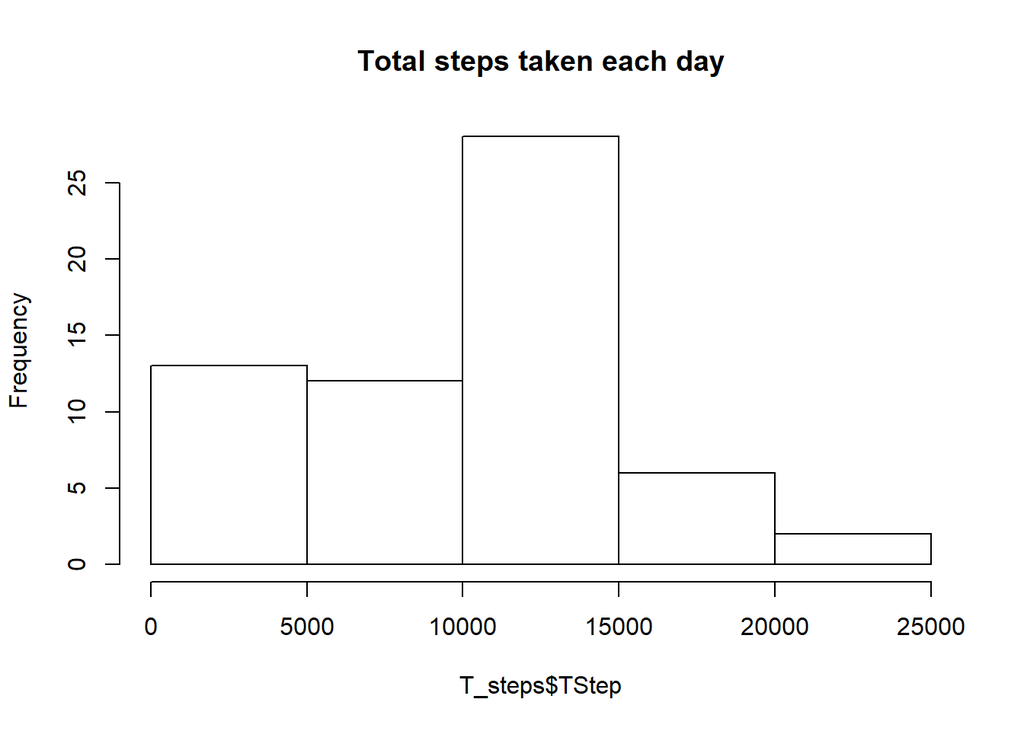

```r
hist(T_steps$TStep, main="Total steps taken each day")
```

## Task 3: calculate and report the mean and median of total number of steps taken per day

```r
Step_mean <- mean(T_steps$TStep)
Step_median <- median(T_steps$TStep)
Step_mean
```

```
## [1] 9354.23
```

```r
Step_median
```

```
## [1] 10395
```

# Part 3: Analysing average daily activity pattern

## Task 1: make a time series plot of 5 min interval and average steps taken

```r
A_steps1<- group_by(cleanData,interval)
A_steps<- as.data.frame(summarise(A_steps1,AStep = mean(steps,na.rm=TRUE)))
head(A_steps)
```

```
##   interval     AStep
## 1        0 1.7169811
## 2        5 0.3396226
## 3       10 0.1320755
## 4       15 0.1509434
## 5       20 0.0754717
## 6       25 2.0943396
```

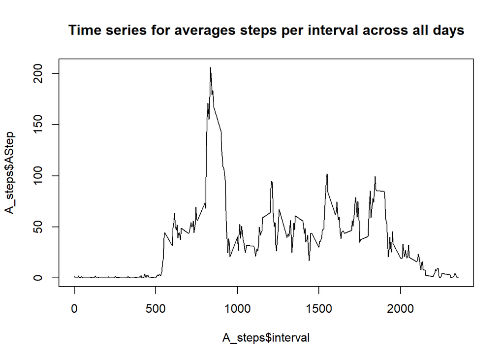

```r
plot(A_steps$interval,A_steps$AStep,type="l",main="Time series for averages steps per interval across all days")
```

##Task 2: find the 5-min interval with highest max number of steps

```r
Max_steps<- as.data.frame(summarise(A_steps1, MStep = max(steps,na.rm=TRUE)))
M_step<- arrange(Max_steps,desc(MStep))
head(M_step,1)
```

```
##   interval MStep
## 1      615   806
```

#Part 4: Inputting misssing values ## Task 1: Calculate and report the total number of missing values

```r
missingValues<- filter(cleanData,is.na(steps))
nrow(missingValues)
```

```
## [1] 2304
```

## Task2: Filling in missing values (with avearage value for that interval)

```r
combinedSteps<- as.data.frame(merge(A_steps,cleanData,by="interval"))
combinedSteps<- combinedSteps %>%
  mutate(newsteps = steps %>%
             is.na %>%
             ifelse(AStep, steps))
head(combinedSteps)
```

```
##   interval    AStep steps       Date newsteps
## 1        0 1.716981    NA 2012-10-01 1.716981
## 2        0 1.716981     0 2012-11-23 0.000000
## 3        0 1.716981     0 2012-10-28 0.000000
## 4        0 1.716981     0 2012-11-06 0.000000
## 5        0 1.716981     0 2012-11-24 0.000000
## 6        0 1.716981     0 2012-11-15 0.000000
```

## Task 3: Create a new dataset with missing values filled in

```r
newcleanData <- combinedSteps %>%
  mutate(Steps=as.integer(newsteps))
newcleanData<- newcleanData[,c(4,1,6,2)]
head(newcleanData)
```

```
##         Date interval Steps    AStep
## 1 2012-10-01        0     1 1.716981
## 2 2012-11-23        0     0 1.716981
## 3 2012-10-28        0     0 1.716981
## 4 2012-11-06        0     0 1.716981
## 5 2012-11-24        0     0 1.716981
## 6 2012-11-15        0     0 1.716981
```

## Task 4

### Sub-task 1: make a histogram of total number of steps taken per day

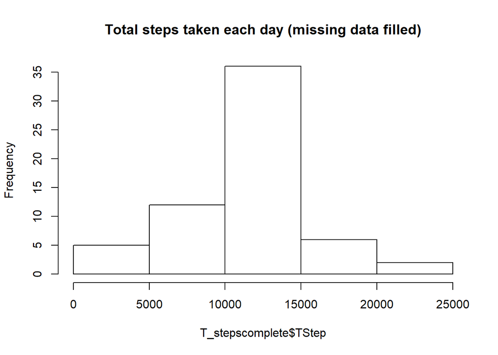

```r
T_steps2<- group_by(newcleanData,Date)
  T_stepscomplete<- summarise(T_steps2, TStep = sum(Steps,na.rm=TRUE))
  hist(T_stepscomplete$TStep, main="Total steps taken each day (missing data filled)")
```

### Sub-task 2: calculate new mean an median each day

```r
Step_meancomplete <- mean(T_stepscomplete$TStep)
Step_mediancomplete <- median(T_stepscomplete$TStep)
Step_meancomplete
```

```
## [1] 10749.77
```

```r
Step_mediancomplete
```

```
## [1] 10641
```

### Sub-tasks 3 & 4: do these values differ from results calculated in task 1?

### What is the impact?

```r
delta1<- Step_mean-Step_meancomplete
delta2<- Step_median-Step_mediancomplete
delta1
```

```
## [1] -1395.541
```

```r
delta2
```

```
## [1] -246
```

```r
#### The mean and median steps per day calculated before
#### were less those after missing values were replaced.
#### By replacing missing vlaues, the daily mean and median
#### were increased.
```

#Part 5: Activity patterns during weekend and weekdays ## Task 1: create a new factor indicating whether a day is weekday or weekend

```r
library(lubridate)
newcleanData1<- mutate(newcleanData,Weekday=wday(newcleanData$Date,week_start=1))
weekenddata<- filter(newcleanData1,Weekday>5)
weekdaydata<- filter (newcleanData1, Weekday<6)
weekenddata1<- mutate(weekenddata,WDAY="Weekend")
weekdaydata1<- mutate(weekdaydata,WDAY="Weekday")
newData1<- rbind(weekenddata1,weekdaydata1)
newData<- select(newData1,-Weekday)
head(newData)
```

```
##         Date interval Steps    AStep    WDAY
## 1 2012-10-28        0     0 1.716981 Weekend
## 2 2012-11-24        0     0 1.716981 Weekend
## 3 2012-10-20        0     0 1.716981 Weekend
## 4 2012-11-25        0     0 1.716981 Weekend
## 5 2012-11-04        0     1 1.716981 Weekend
## 6 2012-11-18        0     0 1.716981 Weekend
```

```r
str(newData)
```

```
## 'data.frame':    17568 obs. of  5 variables:
##  $ Date    : Date, format: "2012-10-28" "2012-11-24" ...
##  $ interval: int  0 0 0 0 0 0 0 0 0 0 ...
##  $ Steps   : int  0 0 0 0 1 0 0 0 0 0 ...
##  $ AStep   : num  1.72 1.72 1.72 1.72 1.72 ...
##  $ WDAY    : chr  "Weekend" "Weekend" "Weekend" "Weekend" ...
```

## Task 2: make a panel plot

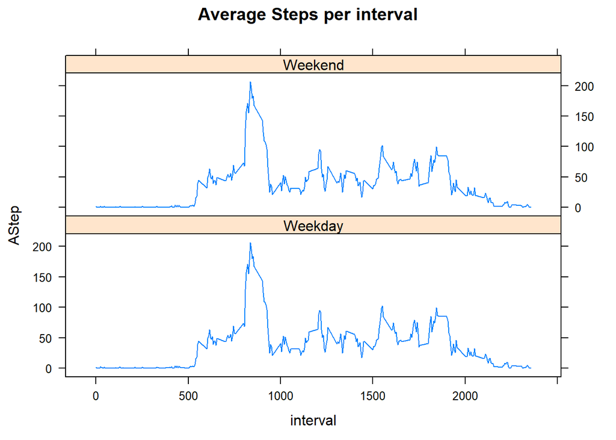

```r
library(lattice)
xyplot(AStep ~ interval | WDAY, data=newData1 ,type="l", layout=c(1,2),
    main="Average Steps per interval")
```